# Reporte 1: tiempos de llegada

## Procesamiento

### Datos

- Muestra seleccionada
- Remesas (datos observados de la muestra seleccionada en la noche de la elección, hasta medianoche)
- Conteos distritales

```r
library(lubridate)
library(patchwork)
library(survival)
library(survminer)
library(ggfortify)
library(broom)
source("./simulacion_tiempos.R")
```

### Muestra seleccionada

```r
# Id de estados
estados_tbl <- read_csv("../datos/df_mxstate.csv")
muestra_selec <- read_csv("../datos/4-ConteoRapido18MUESTRA-ELECCION-PRESIDENCIAL.csv") %>%
  mutate(CLAVE_CASILLA = paste0(str_sub(ID, 2, 3), str_sub(ID, 6, -1)))
nrow(muestra_selec)
```

```
## [1] 7787
```

```r
muestra_selec
```

```
## # A tibble: 7,787 x 19
##    ID    iD_ESTADO ID_DISTRITO_FED… SECCION TIPO_CASILLA ID_CASILLA EXT_CONTIGUA
##    <chr> <chr>     <chr>              <dbl> <chr>             <dbl>        <dbl>
##  1 A010… 01        01                   344 C                     3            0
##  2 A010… 01        01                   356 C                     1            0
##  3 A010… 01        01                   358 B                     1            0
##  4 A010… 01        01                   362 S                     1            0
##  5 A010… 01        01                   363 B                     1            0
##  6 A010… 01        01                   363 C                     2            0
##  7 A010… 01        01                   370 C                     1            0
##  8 A010… 01        01                   377 C                     1            0
##  9 A010… 01        01                   390 C                     1            0
## 10 A010… 01        01                   392 C                     7            0
## # … with 7,777 more rows, and 12 more variables: TIPO_SECCION <dbl>,
## #   LISTA_NOMINAL <dbl>, ID_MUNICIPIO <dbl>, ID_DIST_LOC <dbl>,
## #   ID_ESTRATO_F <dbl>, ESTRATO_F <lgl>, ID_ESTRATO_L <dbl>, ESTRATO_L <lgl>,
## #   ID_AREA_RESPONSABILIDAD <dbl>, NUM_ZORE <dbl>, CIRCUNSCRIPCION <dbl>,
## #   CLAVE_CASILLA <chr>
```

### Conteos

```r
encabezado <- read_lines("../datos/presidencia.csv", skip = 6, n_max = 1) %>%
  str_replace("\\|\\|", "") %>%
  str_split_fixed("\\|", n = 42)
conteo <- read_delim("../datos/presidencia.csv", delim = "|",
                     col_names = encabezado,
                     skip = 7,
                     quote = "'", na = c("", "NA", "-")) %>%
  mutate(AMLO_1 = MORENA + PT + `ENCUENTRO SOCIAL` + PT_MORENA +
                  MORENA_PES + PT_PES + PT_MORENA_PES,
         RAC_1 = PAN + PRD + `MOVIMIENTO CIUDADANO` + PAN_PRD + PAN_MC +
                 PRD_MC + PAN_PRD_MC,
         JAMK_1 = PRI + PVEM + `NUEVA ALIANZA` + PRI_PVEM + PRI_NA +
                  PVEM_NA + PRI_PVEM_NA) %>%
  left_join(estados_tbl %>%
                rename(ID_ESTADO = region) %>%
                mutate(ID_ESTADO = as.numeric(ID_ESTADO)),
              by = "ID_ESTADO") %>%
  filter(TIPO_CASILLA != "M") %>%
  mutate(tipo_casilla = factor(TIPO_CASILLA, levels= c("B", "C", "E", "S"))) %>%
  mutate(lista_nominal_log = log(1 + LISTA_NOMINAL_CASILLA)) %>%
  mutate(huso = case_when(state_abbr %in% c("BC", "SON") ~ 2,
                            state_abbr %in% c("CHIH", "BCS", "NAY", "SIN") ~ 1,
                            TRUE ~ 0))
```

```r
# recuperar conteos de muestra completa
datos_muestra <- muestra_selec %>%
    left_join(conteo %>%
      select(CLAVE_CASILLA, LISTA_NOMINAL_CASILLA, AMLO_1:JAMK_1,
             TOTAL_VOTOS_CALCULADOS, lista_nominal_log, huso, tipo_casilla) %>%
      rename(LISTA_NOMINAL = LISTA_NOMINAL_CASILLA),
      by = c("CLAVE_CASILLA", "LISTA_NOMINAL"))

# casillas de la muestra con faltantes:
datos_muestra %>% group_by(is.na(AMLO_1)) %>%
  count()
```

```
## # A tibble: 2 x 2
## # Groups:   is.na(AMLO_1) [2]
##   `is.na(AMLO_1)`     n
##   <lgl>           <int>
## 1 FALSE            7763
## 2 TRUE               24
```

```r
datos_muestra <- datos_muestra %>%
  filter(!is.na(AMLO_1)) %>%
  left_join(estados_tbl %>% mutate(iD_ESTADO = region)) %>%
  mutate(huso = case_when(state_abbr %in% c("BC", "SON") ~ 2,
                          state_abbr %in% c("CHIH", "BCS", "NAY", "SIN") ~ 1,
                          TRUE ~ 0))
```

```r
# muestra obtenida por hora de llegada, calcular huso
# Clave casilla: ID_ESTADO-SECCION-TIPO_CASILLA-ID_CASILLA-EXT_CONTIGUA
remesas <- read_delim("../datos/remesas_nal/remesas_nal/REMESAS0100020000.txt",
                      delim = "|", skip = 1) %>%
  mutate(timestamp = ymd_hms(paste(ANIO, MES, DIA, HORA, MINUTOS, SEGUNDOS, sep = "-"),
                             tz = "America/Mexico_City")) %>%
  mutate(ID_ESTADO = str_pad(iD_ESTADO, 2, pad = "0"),
         SECCION = str_pad(SECCION,4, pad = "0"),
         TIPO_CASILLA = ifelse(TIPO_CASILLA == "MEC", "M", TIPO_CASILLA),
         ID_CASILLA = str_pad(ID_CASILLA, 2, pad = "0"),
         EXT_CONTIGUA = str_pad(EXT_CONTIGUA, 2, pad = "0")) %>%
  mutate(CLAVE_CASILLA = paste0(ID_ESTADO, SECCION, TIPO_CASILLA, ID_CASILLA, EXT_CONTIGUA))
```

```r
muestra_tot <-
  left_join(
    datos_muestra %>% select(CLAVE_CASILLA, LISTA_NOMINAL, TIPO_SECCION,
             ID_ESTRATO_F, ID_AREA_RESPONSABILIDAD, state_abbr,
             TOTAL_VOTOS_CALCULADOS, tipo_casilla, lista_nominal_log,
             TIPO_CASILLA, LISTA_NOMINAL, huso, AMLO_1:JAMK_1),
    remesas %>% select(-TIPO_SECCION, - TIPO_CASILLA),
    by = c("CLAVE_CASILLA", "LISTA_NOMINAL")) %>%
  mutate(llegada = ifelse(is.na(TOTAL), 0, 1))
```

## Análisis exploratorio

El tiempo lo medimos desde 18:30:

```r
# Construir datos de llegadas
llegadas_tbl <- muestra_tot %>%
  select(timestamp, huso, llegada, state_abbr, TIPO_CASILLA, RAC_1, JAMK_1, AMLO_1,
         lista_nominal_log,
         TOTAL_VOTOS_CALCULADOS,
         LISTA_NOMINAL, ID_ESTRATO_F.x, ID_AREA_RESPONSABILIDAD.x,
                                   TOTAL, TIPO_SECCION, ID_ESTADO) %>%
  mutate(timestamp = if_else(is.na(timestamp),
              ymd_hms("2018-07-01 23:59:59", tz = "America/Mexico_City"), timestamp)) %>%
  mutate(timestamp = with_tz(timestamp, "America/Mexico_City")) %>%
  mutate(tiempo = difftime(timestamp,
                           ymd_hms("2018-07-01 18:30:00", tz ="America/Mexico_City"),
                           units = "hours")) %>%
  mutate(tipo_casilla = factor(TIPO_CASILLA),
         tipo_seccion = factor(TIPO_SECCION)) %>%
  mutate(cae = paste0(ID_ESTRATO_F.x, ID_AREA_RESPONSABILIDAD.x)) %>%
  group_by(cae) %>%
  mutate(n_reporte = rank(timestamp)) %>%
  ungroup %>%
  group_by(state_abbr) %>%
  mutate(grupo_ln = cut_number(LISTA_NOMINAL, 5)) %>%
  mutate(status = llegada)
```

LLegadas por hora

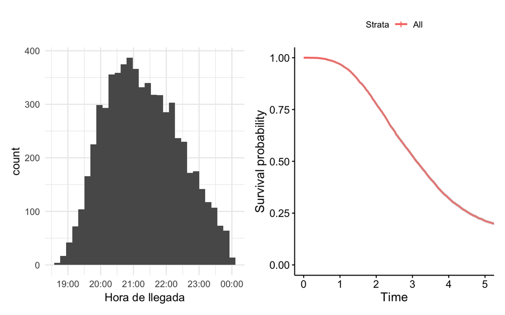

```r
g_1 <- ggplot(llegadas_tbl %>% filter(llegada==1),
       aes(x = with_tz(timestamp, "America/Mexico_City"))) +
  geom_histogram() + xlab("Hora de llegada")
g_2 <- ggsurvplot(survfit(Surv(tiempo, status) ~ 1, llegadas_tbl), conf.int = TRUE)
g_1 + g_2$plot
```

Y para cada estado, según tamaño de la lista nominal, tipo de sección y tamaño de lista nominal está correlacionado, por ejemplo en Michoacán:

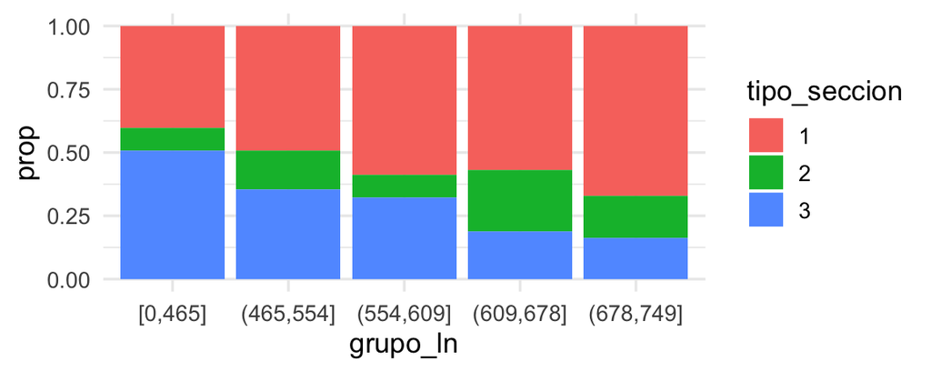

```r
llegadas_tbl %>% filter(state_abbr == "MICH") %>%
  group_by(grupo_ln, tipo_seccion) %>% count() %>%
  group_by(grupo_ln) %>%
  mutate(prop = n / sum(n)) %>%
ggplot(aes(x = grupo_ln, y = prop, fill = tipo_seccion, group = tipo_seccion)) +
  geom_col()
```

Pero menos en Chihuahua:

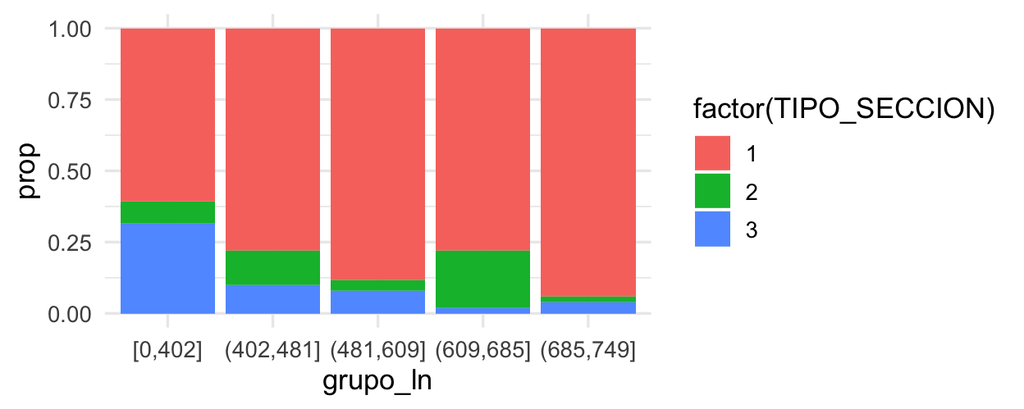

```r
llegadas_tbl %>% filter(state_abbr == "CHIH") %>%
  group_by(grupo_ln, TIPO_SECCION) %>% count() %>%
  group_by(grupo_ln) %>%
  mutate(prop = n / sum(n)) %>%
ggplot(aes(x = grupo_ln, y = prop, fill = factor(TIPO_SECCION), group = TIPO_SECCION)) +
  geom_col()
```

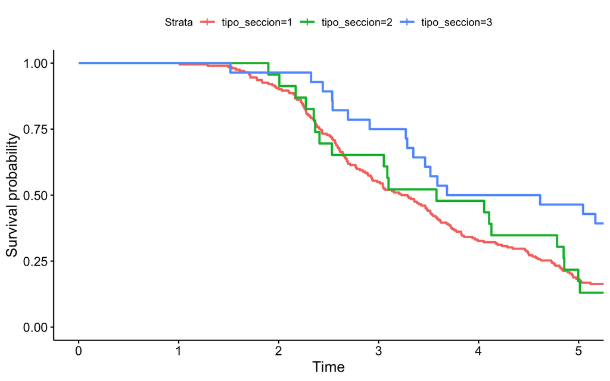

```r
ggsurvplot(fit = survfit(Surv(tiempo, status) ~ tipo_seccion,
                   llegadas_tbl %>% filter(state_abbr == "CHIH")),
           data = llegadas_tbl)
```

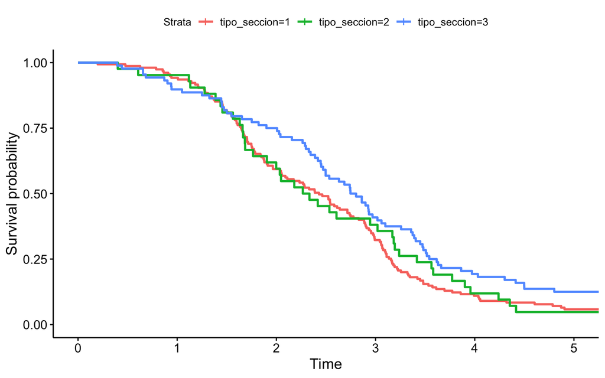

```r
ggsurvplot(survfit(Surv(tiempo, status) ~ tipo_seccion ,
                   llegadas_tbl %>% filter(state_abbr == "MICH")),
           data = llegadas_tbl)
```

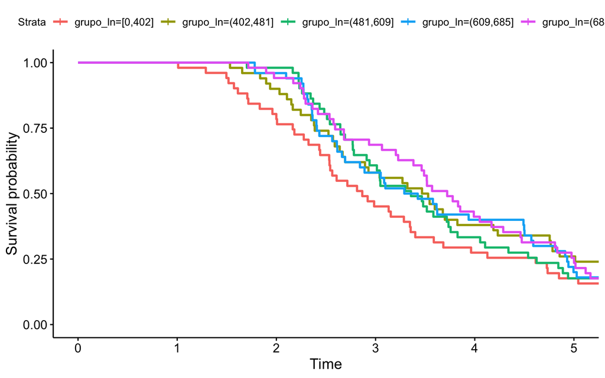

```r
ggsurvplot(fit = survfit(Surv(tiempo, status) ~ grupo_ln,
                   llegadas_tbl %>% filter(state_abbr == "CHIH")),
           data = llegadas_tbl)
```

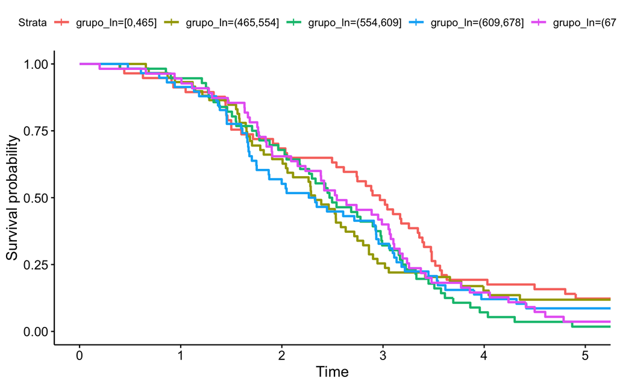

```r
ggsurvplot(survfit(Surv(tiempo, status) ~ grupo_ln ,
                   llegadas_tbl %>% filter(state_abbr == "MICH")),
           data = llegadas_tbl)
```

## Modelos paramétricos

Tratamos varios modelos:

### Regresión log-normal

```r
estados <- c("ZAC", "COL", "CHIH", "MICH", "NAY")
media_ln_log  <- mean(llegadas_tbl$lista_nominal_log)
llegadas_tbl_2 <- llegadas_tbl %>% filter(state_abbr %in% estados) %>%
                  ungroup %>%
                  mutate(grupo_ln = cut_number(LISTA_NOMINAL, 3)) %>%
                  mutate(tiempo_huso = ifelse(tiempo - huso > 0, tiempo - huso, 0.001)) %>%
                  mutate(ln_log_c = lista_nominal_log - mean(lista_nominal_log))
reg_2 <- survreg(Surv(tiempo_huso, status) ~ 1 +
                   ln_log_c +
                   tipo_casilla +
                   #tipo_seccion +
                   #state_abbr:log(1+RAC_1/total_3) +
                   state_abbr:log(1+AMLO_1/(TOTAL_VOTOS_CALCULADOS + 1)) +
                   state_abbr:log(1+JAMK_1/(TOTAL_VOTOS_CALCULADOS +  1)) +
                   state_abbr:ln_log_c +
                   #state_abbr:tipo_seccion:ln_log_c +
                   strata(state_abbr),
                   llegadas_tbl_2,
                 dist='lognormal', control = survreg.control(maxiter = 5000))
reg_2 %>% tidy() %>%  DT::datatable()
```

|  | term | estimate | std.error | statistic | p.value |
| --- | --- | --- | --- | --- | --- |
| 1 | (Intercept) | 0.368083569988479 | 0.18009219880584 | 2.0438618242721 | 0.0409671994504358 |
| 2 | ln_log_c | 0.364702871543472 | 0.107381113676775 | 3.39634093050341 | 0.000682932388466112 |
| 3 | tipo_casillaC | -0.0612737349768688 | 0.0543471652402832 | -1.12745043289675 | 0.259552086259536 |
| 4 | tipo_casillaE | 0.228439984288835 | 0.137299663404597 | 1.66380585810807 | 0.0961512329312973 |
| 5 | tipo_casillaS | 2.08094213738037 | 0.623152905087374 | 3.33937645221857 | 0.000839666916289861 |
| 6 | state_abbrCHIH:log(1 + AMLO_1/(TOTAL_VOTOS_CALCULADOS + 1)) | 0.987352974638117 | 0.413954318789948 | 2.38517374942313 | 0.0170710566001006 |
| 7 | state_abbrCOL:log(1 + AMLO_1/(TOTAL_VOTOS_CALCULADOS + 1)) | 0.0529471147197715 | 0.496563710953642 | 0.10662703204406 | 0.915084872365887 |
| 8 | state_abbrMICH:log(1 + AMLO_1/(TOTAL_VOTOS_CALCULADOS + 1)) | 0.69841615161173 | 0.355674277854253 | 1.9636397543989 | 0.0495718837209753 |
| 9 | state_abbrNAY:log(1 + AMLO_1/(TOTAL_VOTOS_CALCULADOS + 1)) | 0.172247745607488 | 0.540646943452732 | 0.318595615296486 | 0.750033178804688 |
| 10 | state_abbrZAC:log(1 + AMLO_1/(TOTAL_VOTOS_CALCULADOS + 1)) | 0.732162507970318 | 0.454035289944999 | 1.61256740210438 | 0.106838525358488 |

[output cut: 14 more lines]

### Simulación y ajuste

```r
datos_sim <- map(1:70, ~ simular_lognormal(.x, llegadas_tbl_2, reg_2))
gg_obs <- ggsurvplot(survfit(Surv(tiempo_huso, status)~ state_abbr, llegadas_tbl_2))
datos_obs <- gg_obs$data.survplot %>% mutate(id = 71)
datos_check <- bind_rows(datos_obs, datos_sim)
```

### Diagnósticos

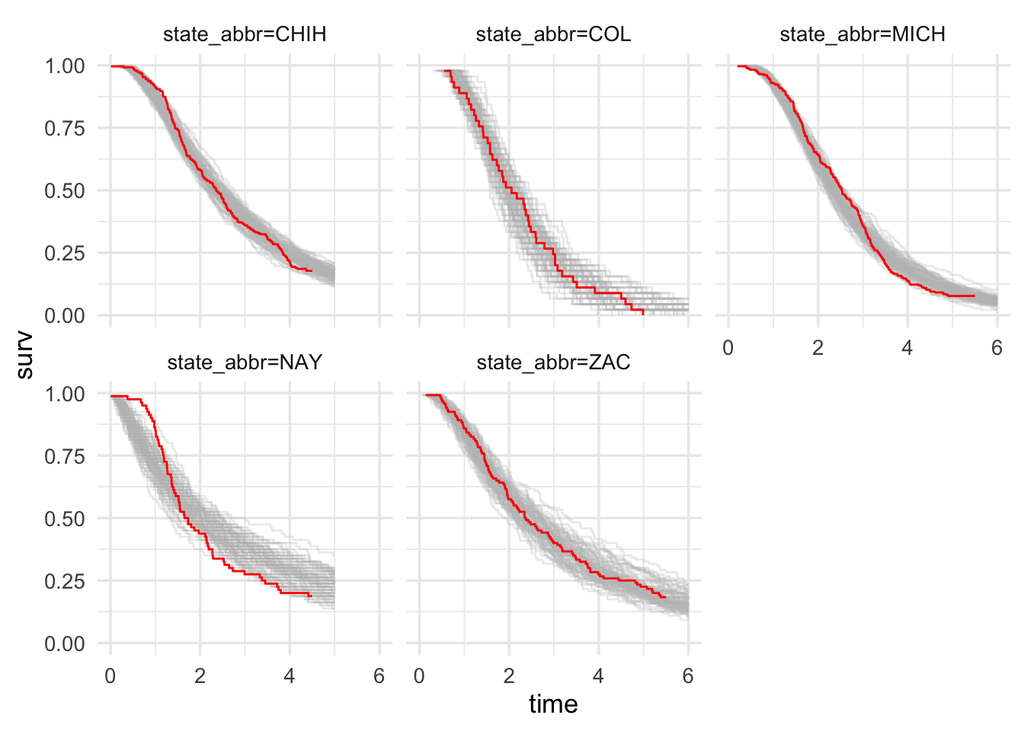

```r
ggplot(datos_check %>% filter(id!=71), aes(x = time, y = surv, group = id)) +
  geom_step( alpha = 0.3, colour = "gray") +
  geom_step(data = datos_check %>% filter(id==71), colour = "red") +
  facet_wrap(~ strata)
```

### Ejemplo de simulación

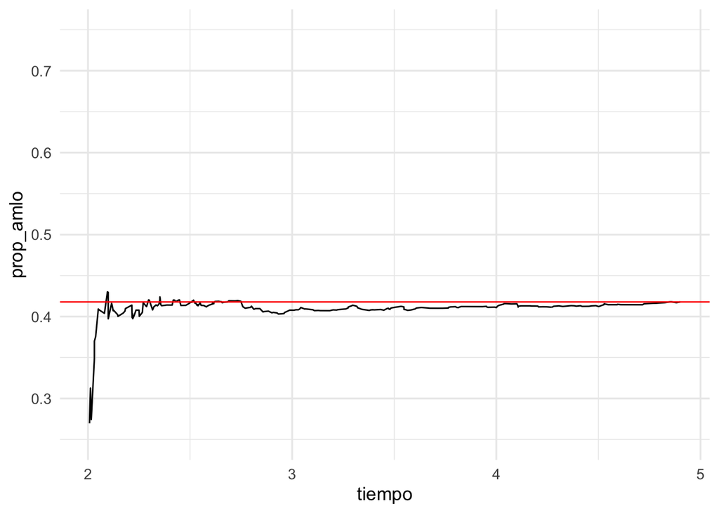

```r
muestra_tbl <- seleccionar_muestra(conteo, prop = 0.1, "CHIH")
tiempos_sim <- simular_lognormal(1, muestra_tbl, reg_2, solo_tiempos = TRUE)

muestra_tiempo <- bind_cols(tiempos_sim, muestra_tbl %>% select(-state_abbr))

graficar_acumulado <- function(muestra_tiempo){
  datos <- muestra_tiempo %>% arrange(tiempo) %>%
    mutate(acumulado_amlo = cumsum(AMLO_1), acumulado_tot = cumsum(TOTAL_VOTOS_CALCULADOS)) %>%
    mutate(prop_amlo = acumulado_amlo / acumulado_tot)
  prop <- last(datos$prop_amlo)
  ggplot(datos, aes(x = tiempo, y = prop_amlo)) + geom_line() +
    geom_hline(yintercept = prop, colour = "red")
}
g_1 <- graficar_acumulado(muestra_tiempo %>% filter(status == 1, tiempo > 2)) +
  ylim(c(0.25,0.75))
g_1
```

Evaluar en 3 horas vs muestra total:

```r
cortes = c(1.5, 2.5, 3, 3.5, 4, 4.5, 5.5)
#cortes <- c(50, 100, 150, 200, 300, 600)

simular_cortes <- function(cortes = cortes, prop_muestra = 0.3) {
  evaluacion_tbl <- map(cortes, function(corte) {
    reps_tbl <- map(1:300, function(rep){
      # estado y porcentaje
      muestra_tbl <- seleccionar_muestra(conteo, prop = prop_muestra, "MICH")
      tiempos_sim <- simular_lognormal(1, muestra_tbl, reg_2, solo_tiempos = TRUE)
      datos <- bind_cols(tiempos_sim, muestra_tbl %>% select(-state_abbr)) %>%
        arrange(tiempo) %>%
        mutate(acumulado_cand = cumsum(RAC_1),
               acumulado_tot = cumsum(TOTAL_VOTOS_CALCULADOS),
               num_casillas = row_number()) %>%
        mutate(prop_cand = acumulado_cand / acumulado_tot)
    #prop_corte <- datos %>% filter(num_casillas <= corte) %>% pull(prop_amlo) %>% last
    #hora_salida <- datos %>% filter(num_casillas <= corte) %>% pull(tiempo) %>% last
    prop_corte <- datos %>% filter(tiempo <= corte) %>% pull(prop_cand) %>% last
    hora_salida <- datos %>% filter(tiempo <= corte) %>% pull(tiempo) %>% last
    prop <- datos %>% pull(prop_cand) %>% last
    tibble(prop_corte = prop_corte, prop = prop, hora_salida = hora_salida)
  }) %>% bind_rows %>%
      mutate(corte = corte)
  }) %>% bind_rows %>%
    mutate(prop_muestra = prop_muestra)
}
eval_tbl_1 <- simular_cortes(cortes, 0.05)
eval_tbl_2 <- simular_cortes(cortes, 0.10)
eval_tbl_3 <- simular_cortes(cortes, 0.20)
evals_tbl <- bind_rows(eval_tbl_1, eval_tbl_2, eval_tbl_3)
```

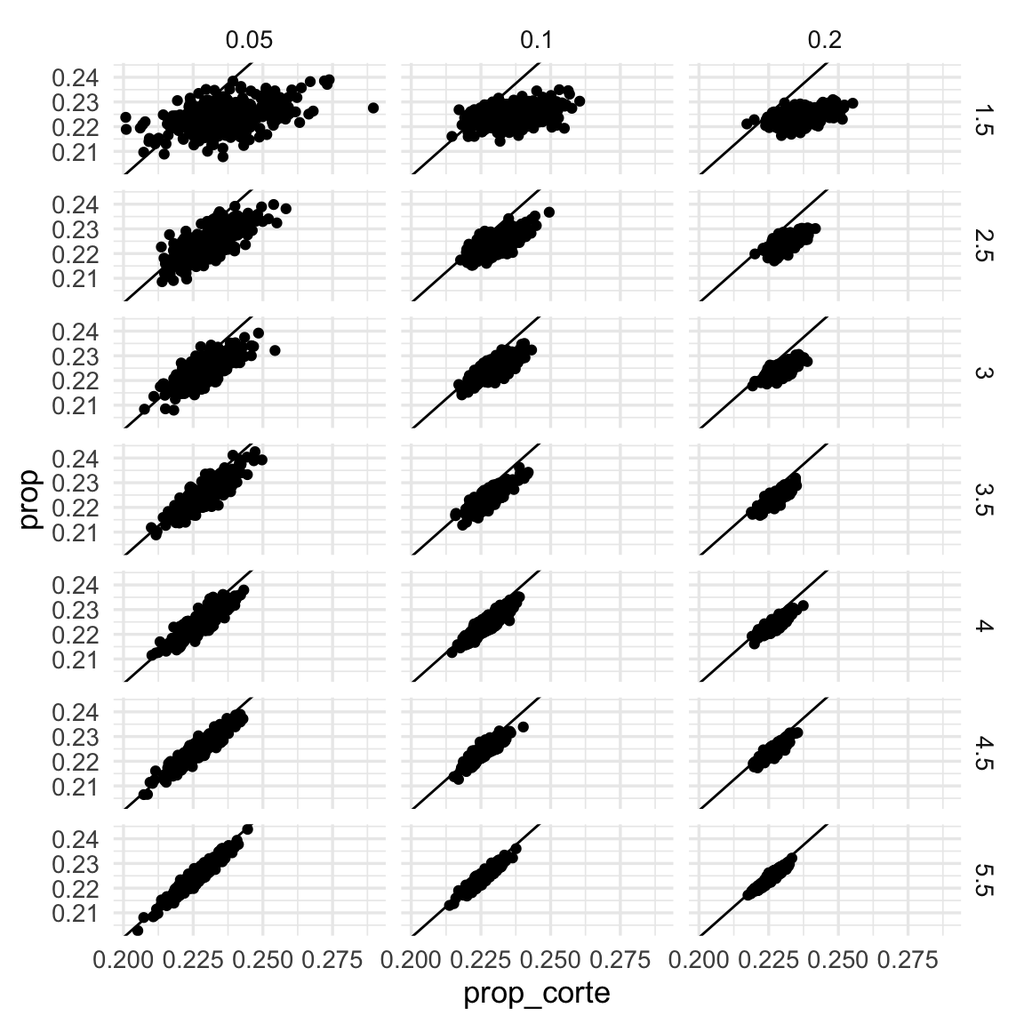

```r
ggplot(evals_tbl, aes(x= prop_corte, y= prop)) + geom_point() +
  geom_abline() + facet_grid(corte ~ prop_muestra)
```

Proporción

```r
total <- seleccionar_muestra(conteo, prop = 1, "MICH")
prop_real <- sum(total$RAC_1, na.rm = T)/
  sum(total$TOTAL_VOTOS_CALCULADOS, na.rm = T)
```

Podemos ver que entre mayor es la muestra, menor es el error cuadrático medio fijando cualquier hora.

```r
ecm_tbl <- evals_tbl %>% mutate(prop_v = prop_real) %>%
  group_by(corte, prop_muestra) %>%
  summarise(sesgo_2 = (mean(prop_corte) - prop_real)^2,
            varianza = var(prop_corte)) %>%
  ungroup %>%
  mutate(recm = sqrt(sesgo_2 + varianza))
ecm_tbl
```

```
## # A tibble: 21 x 5
##    corte prop_muestra   sesgo_2  varianza    recm
##    <dbl>        <dbl>     <dbl>     <dbl>   <dbl>
##  1   1.5         0.05 0.000172  0.000182  0.0188
##  2   1.5         0.1  0.000167  0.0000737 0.0155
##  3   1.5         0.2  0.000147  0.0000420 0.0137
##  4   2.5         0.05 0.0000423 0.0000652 0.0104
##  5   2.5         0.1  0.0000385 0.0000298 0.00826
##  6   2.5         0.2  0.0000445 0.0000123 0.00753
##  7   3           0.05 0.0000248 0.0000498 0.00864
##  8   3           0.1  0.0000270 0.0000251 0.00722
##  9   3           0.2  0.0000252 0.0000101 0.00594
## 10   3.5         0.05 0.0000226 0.0000439 0.00816
## # … with 11 more rows
```

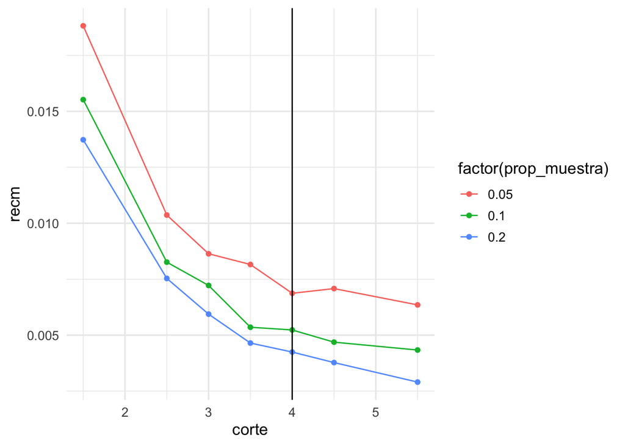

```r
ggplot(ecm_tbl, aes(x = corte, y = recm,
                    colour = factor(prop_muestra),
                    group=prop_muestra)) +
  geom_point() + geom_line() + geom_vline(xintercept = 4)
```

El error cuadrático medio es la suma del sesgo cuadrado y la varianza. Podemos observar también que, fijando cualquier hora, la proporción del error cuadrático medio que corresponde a la varianza es menor para muestras grandes.

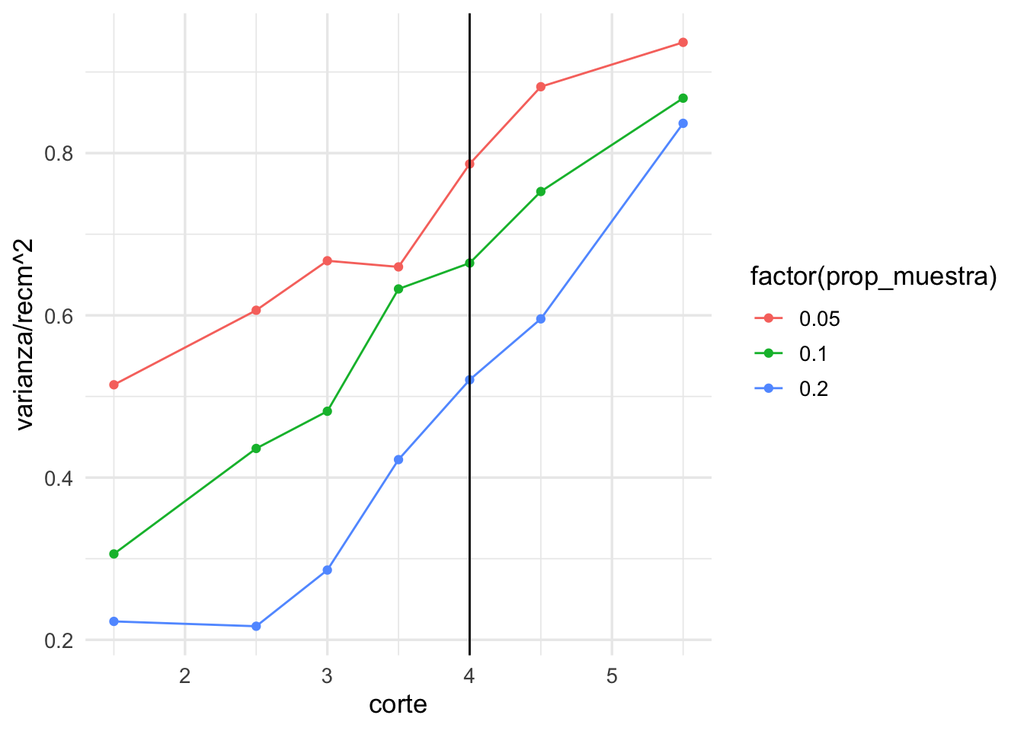

```r
ggplot(ecm_tbl, aes(x = corte, y = varianza / recm^2,
                    colour = factor(prop_muestra),
                    group=prop_muestra)) +
  geom_point() + geom_line() + geom_vline(xintercept = 4)
```

Consecuentemente, la proporción del error cuadrático medio que corresponde al sesgo es mayor entre mayor sea la muestra.

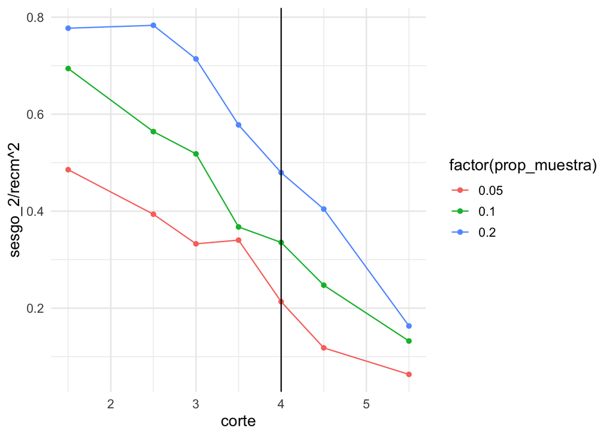

```r
ggplot(ecm_tbl, aes(x = corte, y = sesgo_2 / recm^2,
                    colour = factor(prop_muestra),
                    group=prop_muestra)) +
  geom_point() + geom_line() + geom_vline(xintercept = 4)
```

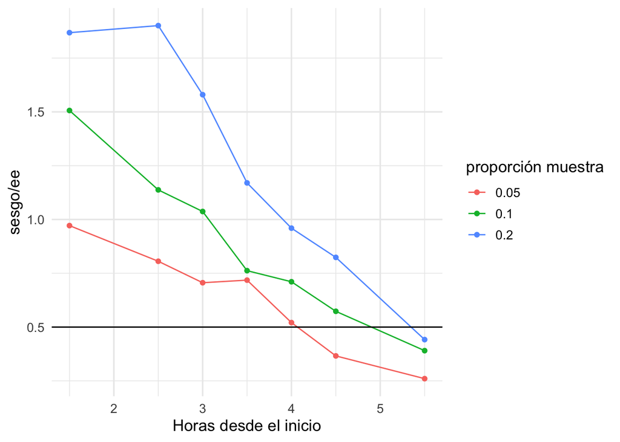

```r
ggplot(ecm_tbl, aes(x = corte, y = sqrt(sesgo_2/varianza),
                    colour = factor(prop_muestra),
                    group=prop_muestra)) +
  geom_point() + geom_line() +
  geom_hline(yintercept = 0.5) +
  ylab("sesgo/ee") + xlab("Horas desde el inicio") +
  labs(colour = "proporción muestra")
```